# Assignment 3: Image Colourization [50 Pt]

### Part (v) [2pt DISCUSSION]

There are two ways to implement the conditional GAN. The first is a standard conditional GAN for which the generator is a decoder with an input that is random noise with a conditional. The second is the pix2pix architecture where the generator is a UNet architecture with a greyscale image input.

Briefly describe the pros and cons of the two different approaches in regards to the image colourization task.

Limit your answer to no more than 100 words.

```python
'''
PROVIDE YOUR ANSWER BELOW
Standard cGAN:
- pros:
    - diverse output since the generator takes random noise
- cons:
    - hard to train: the training for cGAN is unstable

Pix2Pix:
- pros:
    - preserve spatial information due to skip connections in UNET
- cons:
    - since it has no random noise initially, the training is more stable
'''
```

[output not shown]

## Part 2 New Data [7 Pt]

### Part (i) [5pt RESULTS]

Download the grayscale horse images provided [here](https://drive.google.com/file/d/1xlRmv3SRY6Qi5XrXPFsCs8xtbP6OBT30/view?usp=sharing) and use your best model to perform image colourization on all the 302 images. Provide all your code, including any image processing that you need to perform.

Print out several grayscale images from the provided dataset along with their colourized versions by your best model.

Report the colourized images by your chosen model as a single compressed [NPZ](https://numpy.org/doc/stable/reference/generated/numpy.savez_compressed.html) file called 'colourized.npz', containing the numpy array of type `float32` with the shape `(302, 32, 32, 3)`.

For grading, Fréchet Inception Distance (FID) will be used on your colourized images to compare the original colour images and your colourized images. The assumption is that if the colourization process is successful, the distribution of features learned by the network should be similar between the two sets of images. The following links provide more details about how FID is used for evaluation [link1](https://machinelearningmastery.com/how-to-implement-the-frechet-inception-distance-fid-from-scratch/), [link2](https://wandb.ai/ayush-thakur/gan-evaluation/reports/How-to-Evaluate-GANs-using-Frechet-Inception-Distance-FID---Vmlldzo0MTAxOTI), [link3](https://generativeai.pub/image-colorization-bringing-black-and-white-to-life-b14d3e0db763).

#### Load data

```python
# TO BE COMPLETED
import os
import cv2
import numpy as np
import torch
from skimage.color import rgb2lab, lab2rgb
import matplotlib.pyplot as plt
import random

def load_and_preprocess_images(folder_path, target_size=(32, 32)):
    image_list = []
    original_images = []

    for filename in os.listdir(folder_path):
        img_path = os.path.join(folder_path, filename)
        img = cv2.imread(img_path, cv2.IMREAD_GRAYSCALE)

        # Resize to target size (32x32)
        img_resized = cv2.resize(img, target_size, interpolation=cv2.INTER_AREA)
        original_images.append(img_resized)
        img_resized = img_resized / 255.0

        # Convert to torch tensor and add batch & channel dimensions
        img_tensor = torch.tensor(img_resized, dtype=torch.float32).unsqueeze(0)  # (1, 32, 32)
        image_list.append(img_tensor)

    if not image_list:
        raise ValueError("No valid images found in the directory.")

    return torch.stack(image_list), original_images

def colorize_images(model, images):
    model.eval()
    with torch.no_grad():
        fake_ab = model(images)  # Predict AB channels

    # Convert from [-1, 1] range to LAB space
    fake_ab = fake_ab * 128  # Scale back from [-1, 1] -> [-128, 127]

    # Convert to RGB images
    colorized_images = []
    for i in range(fake_ab.shape[0]):
        # Get L channel
        L_channel = images[i].squeeze(0).cpu().numpy() * 100  # Scale L from [0, 1] to [0, 100]
        AB_channels = fake_ab[i].cpu().numpy().transpose(1, 2, 0)  # (H, W, 2)

        # Combine L and AB to form LAB image
        lab_image = np.concatenate([L_channel[:, :, np.newaxis], AB_channels], axis=-1)
        rgb_image = lab2rgb(lab_image)
        colorized_images.append(rgb_image)

    return colorized_images

def visualize_results(original_images, colorized_images, num_samples=5):
    num_samples = min(num_samples, len(original_images))
    indices = random.sample(range(len(original_images)), num_samples)

    fig, axes = plt.subplots(2, num_samples, figsize=(12, 6))

    for i, idx in enumerate(indices):
        axes[0, i].imshow(original_images[idx], cmap="gray")
        axes[0, i].axis("off")
        axes[1, i].imshow(colorized_images[idx])
        axes[1, i].axis("off")

    plt.show()
```

#### Model Inference

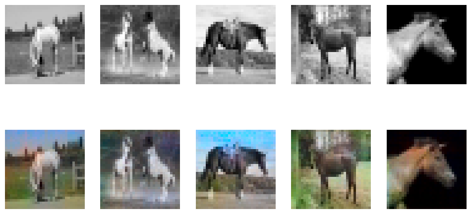

```python
image_folder = "grayimages"
processed_images, original_images = load_and_preprocess_images(image_folder)

model_path = r"C:\Users\Austin\Documents\MEng_Courses\MIE1517-Intro-to-Deep-Learning\2_Assignments\A3_GAN\outputs\colourization_cnn\trained_cGAN_colorizer.pth"
device = torch.device("cuda" if torch.cuda.is_available() else "cpu")
processed_images = processed_images.to(device)

model = Generator(kernel=3, num_filters=20, num_colours=2, num_in_channels=1).to(device)
model.load_state_dict(torch.load(model_path, map_location=device, weights_only=True))  # Load trained weights

colorized_images = colorize_images(model, processed_images)
np.savez_compressed("colourized.npz", colorized_images)
visualize_results(original_images, colorized_images)
```

### Part (ii) [2pt DISCUSSION]

Summarize the qualitative performance of your best model on image colourization of new data and provide some reasons why it performs the way it does. Are there certain types of images on which your model works better than on others? Explain.

```python
'''
PROVIDE YOUR ANSWER BELOW
The model demonstrates better performance in colorizing images that has horses and grassy backgrounds, as these
were the most common elements in the training data. As a result, the generated images has a noticable bias towrads red
and green hues. Moreover, the performance worsen when faced with rare objects, since it lacks sufficient exposure to diverse data.
'''
```

[output not shown]

## Part 3 Exploration [6 Pt]

At this point we have trained a few different generative models for our image colourization task with varying results. What makes this work exciting is that there are many other approaches we could take. In this part of the assignment you are asked to consider some modifications you could make to improve the results and provide some comments on why those approaches could be beneficial.

### Part (i) [2pt DISCUSSION]

We've seen several times in this course how pretrained models could be used to improve performance on classification tasks. Do you think they could be beneficial in improving our results on the image colourization tasks? If so, would it be helpful to implement them in the discriminative and/or generative networks? Why or why not?

Limit your answers to no more than 100 words.

```python
'''
PROVIDE YOUR ANSWER BELOW
Yes, pretrained models (e.g., ResNet,...etc) can improve the results for the image colourization tasks by serving as encoders in the generator.
The pretrain models can effectively extract high-level semantic features, then one can pretrain the generator using l1_loss function.
Lastly, combining the effect of adversarial training, the model that includes pre-train encoders can produce more vibrant and accurate colors.
'''
```

[output not shown]

### Part (ii) [2pt DISCUSSION]

The CIFAR10 images are 32x32 pixels in resolution. Do you believe that using similar images with a resolution of 256x256 would lead to better results. Why or why not?

Limit your answers to no more than 100 words.

```python
'''
PROVIDE YOUR ANSWER BELOW
Yes, using images with higher resolution could lead to better results since it contain more spatial details, so the models
will be able to learn more details and color distributions. However, this could lead to a drastic increase in computational
power, and also may need data augmentation to generalize the model.
'''
```

[output not shown]

### Part (iii) [2pt DISCUSSION]

A colour space is a choice of mapping of colours into three-dimensional coordinates. Some colours could be close together in one colour space, but further apart in others. The RGB colour space is probably the most familiar to you, the model used in our regression colourization example computes squared error in RGB colour space. But, most state of the art colourization models do not use RGB colour space. How could using the RGB colour space be problematic? Your answer should relate how human perception of colour is different than the squared distance. You may use the Wikipedia article on colour space to help you answer the question.

Limit your answers to no more than 100 words.

```python
'''
PROVIDE YOUR ANSWER BELOW
Using the RGB color space for colorization models may be problematic because it's an non-absolute, device-dependent color space that
doesn't align with human vision. Withoutg ICC profiles, RGB colorization models may produce inaccurate colors. However, LAB space is
perceptual uniformed and aligns better with human color perception, so it's preferred in the colorization task.
'''
```

[output not shown]